# LukeAmatoProbabilisticOptionsResearch

**A Probabilisitc Approach to the Iron Condor Strategy on the S&P 500 Underlying SPY**

This is a research project originally completed for the purposes of CMSC320 - Introduction to Data Science at University of Maryland, College Park. If you are reading this, do NOT switch your tab. Whether you are new to data science, new to finance, have years of experience in both, or are uninterested in either, this data science tutorial WILL have something for you. Not only will I be walking you through the basic data science pipeline, but along the way I will be dropping a bunch of really useful resources on the financial markets, financial derivatives, options trading, etc., explaining and giving my insights a bit more in-depth into options trading, AND I will be revealing my current FAVORITE options trading strategy that I utilize every single month (hint: it’s in the title). So take 10 minutes and let me share with you some of my thoughts and research — you might just learn something... or at least complete your job of grading my project (if this is José or my TA , hi!)

If you would like to listen along to the project, I am going to try to include an audio file at the top of this page, of me talking through all of the prose as well as giving some additional insights, which you should be able to listen to as you scroll down the page! This feature may not be live for a couple weeks, but it is on my to-do list!

As always, feel free to leave a comment on my original blog post and make sure to follow or reach out to me on social media: you can find me on [Instagram](https://www.instagram.com/tomato_tamato_/), [Twitter](https://twitter.com/tomato_tamato_), [LinkedIn](https://www.linkedin.com/in/lukeamato/), and [Facebook](https://www.facebook.com/luke.amato.5/).

If you end up enjoying this project, I encourage you to follow my podcast, [@bagsecuredpod](https://www.instagram.com/bagsecuredpod/) , where I talk about all things personal finance, personal conviction/philosophy, and navigating the current financial system in order to create the life you want for yourself. Aimed toward college students and young adults, but everyone is welcome.

Additional shameless plug but feel free to follow my band, [The Missing Peace](https://linktr.ee/themissingpeace), and/or check out our new EP, [garage](https://push.fm/fl/qhbqwhl5), available on all platforms.

With that, we will now start the data science tutorial: forming a probabilistic iron condor options strategy on the S&P 500.

In this tutorial, we will be walking through all five phases of the basic data science pipeline, including

1. Data collection & curation
2. Data management & representation
3. Exploratory data analysis
4. Hypothesis Testing & Machine Learning
5. Communication of insights attained

But before playing with any data, we need to understand what we are working with, determine why it is important or useful, and obtain some background information on the subject.

Back in 2018, I entered University of Maryland, College Park as an undergrad studying computer science and finance. One of my main professional goals was — and still is — to help innovate in the areas of quantitative analysis, financial engineering, or fintech / financial technology in general.

Around 2019, I started getting more involved in the financial markets, including stocks and stock derivatives. More specifically, I became enthralled with the world of options, a type of financial derivative which gives an investor the right to buy or sell a certian stock at an agreed upon price and date. If you are not familiar with options, I have some great resources for you to look at: First, here is one of my absolute favorite videos on options: ["Options Trading for Beginners (The ULTIMATE In-Depth Guide)"](https://www.youtube.com/watch?v=7PM4rNDr4oI). It is an extremely long video, but if you are interested in understanding options at a deep level, I highly recommend it. You can skip around to different sections of that video based on how much you want to know. Alternatively, here is a quick article from Investopedia explaining [what stock options are](https://www.investopedia.com/terms/s/stockoption.asp), and an [8-minute video](https://www.youtube.com/watch?v=EfmTWu2yn5Q) that tries to quickly explain options at a basic level. Finally, if you want to learn more about what financial derivatives are overall, you can find some information on it [here](https://www.investopedia.com/ask/answers/12/derivative.asp).  
That all being said, an understanding of options or financial derivatives will NOT be necessary to understand the thought process behind my data exploration in this tutorial. However, it will be important to have a basic understanding of what the 'iron condor' strategy is. I will offer two explanations now, one for those who have traded options before and one for those who are less familiar. For those who have traded options before, the iron condor strategy is where you sell two credit spreads -- one bearish call credit spread above the underlying and one bullish put credit spread below the underlyng, with the goal of having the underlying remain within the bounds of your condor by expiration. For those who are less familiar with options, the iron condor strategy can be described as making a bet that the stock price of a company will stay within certain bounds that you set by a certain date. For example, let's say I have a company such as Amazon, and its stock is trading at \$3500 per share. Then, I could make a bet that Amazon stock will not rise above \$4000, and will not fall below \$3000, by a certain date, let's say one month from now. If I make this bet, I will get paid a certain amount of money at the time I make the bet, with the risk that if Amazon does in fact move above or below the bounds I have bet on, I will lose all of that premium I was originally paid, and perhaps more.

If this concept is still a bit unclear, here is a [phenomenal video](https://www.youtube.com/watch?v=6UOk_78nVio) made by Chris from [projectfinance](https://https://www.youtube.com/channel/UCYOHtOzMZGwXBLZX1Ltf78g), one of my favorite Youtube channels. As Chris says in the video, lots of investors love the iron condor options strategy because it is market-neutral, it is limited-risk (meaning you know your maximum risk when entering the trade), and it makes you money when the underlying stock DOES NOT experience large price movements. This strategy exists in contrast to what many people, especially new investors, think happens in the stock market, that prices are extremely volatile and you can lose all your money in an instant, or alternatively, that you can double your money in no time. Neither of these preconceptions are realistic. On the internet, you have a lot of bad-faith players trying to convince young people that they can make a fortune day trading stocks, or worse, day trading options. Most of the 'gurus' do not make money day-trading themselves, but rather from tricking people into buying their $400 courses that will 'teach you how to be rich'. Consumers have caught on to the ploy, but unfortunately this has made many people scared of the stock market and options markets overall.  
Options are not meant to be day-traded, especially not by retail investors, but they do play an integral role in our financial system and that is why it is important and interesting to explore the subject. Additionally, the realm of options has long been reserved for the financial elite, either institutional investors or those with access to the markets. With the rise of the internet, high-frequency order flow, and the adoption of commission-free brokerages, options are more accessible than ever. This does not mean that one should invest in option without the proper knowledge or experience, but it does put stock options in the limelight like never before. This research project serves two purposes for me -- first, to begin utilizing data and computer science in the realm of finance and, secondly, to begin develping and exploring statistically-backed trading strategies that can help me better allocate and capitalize on my investments.

Now, I have been talking a lot about options, finance, and all the rest, but where does data science actually come into this. Well, if you recall earlier when we talked about the iron condor options strategy, we said that we were making a bet that a certain stock would not rise above a certain price and not fall below a certain price. The question is, how do you decide which boundaries to choose? In essence, we need to know within what bounds our underlying stock is likely to stay between. Most investors might choose based on the amount of stock that they own, the price target that they expect for a certain company, or other factors. But for me, I am not utilizing the iron condor as a hedge against any other assets that I own. I wish to use the iron condor as a straight profit-seeking strategy. What if we could predict, with accuracy, what prices a certain stock is likely to stay between in any given week. Well, we can do just that using historical data, confidence intervals, and a little bit of pandas-python magic. I have decided to use the S&P500 ETF (SPY) as my underlying asset for this analysis. The S&P 500 is a stock index containing the top 500 companies in the United States. The reason SPY is so good for trading options is because it is representative of the entire stock market and has an extremely high options volume, allowing traders high liquidity to enter or exit contracts at a moment's notice. So let us go ahead and find some of that data!

**I. Data collection**

One more thing about this tutorial is that I am assuming the reader has a basic understanding of the pyhton coding language. If you do not know anything about python, you will still be able to gain a lot by reading my analysis, especially because I will be showing multiple visualizations as well as explaining my process along the way, so I encourage you to keep on reading!

For data collection, we are lucky that Yahoo Finance and other similar websites have kept track of historical price data for nearly every single stock and ETF that you can think of. It doesn't hurt that you can download this data easily in CSV format. For this analysis, we need a good representation of SPY's price behavior over the past few years. Specifically, I want to look at how much the price of SPY moves per week. For that, I will be importing the 5-year historical weekly data on SPY from Yahoo Finance.

For most of my data science work, I utilize Jupyter Notebooks, but more specifically, Jupyter Notebooks hosted on Google Colab. Google Colab is a project from Google that allows you to create and edit Jupyter Notebooks right in your browser. In addition to the convenience of not having to download any software onto your own machine, the Colab servers have basically any Python package you could think of already downloaded, so that we can easily import and use tools such as Pandas, NumPy, and more without any hassle. For more information on Google Colab, visit [this site](https://www.tutorialspoint.com/google_colab/index.htm).

Below, you will see me importing some important packages and tools that we will utilize throughout the analysis. I have downloaded the historical SPY data onto my machine and am uploading it to Google Colab. Why am I doing this instead of pulling data straight from Yahoo Finance using HTTP WGET or utilizing a web scraper/similar methods? Well, this is way easier! If I wanted to repeat this analysis on a regular basis, or build a high-frequency bot that would take advantage of real-time stock data, of course we would want to use a built-in python method to retrive data over the internet. However, for the purposes of this static analysis, it is a no-brainer for me to use the most painless, convenient method of data collection.

```python
import pandas as pd
import numpy as np
import seaborn as sns
from sklearn.linear_model import LinearRegression
import statsmodels.formula.api as ols
import statsmodels.api as sm
from google.colab import files


files.upload()
```

And there you have it! I suppressed the output of my file upload because it was printing out the entire long CSV, but you get the picture. We are done with the 'data collection' portion of our analysis. It seems trivial enough, but in many cases, you will not have data so easily accessible. Many times, you may have to scrape tables off of web pages or jump through a bunch of hoops just to get usable data. This time, we got off easy.

Next up is the second portion of the data science pipeline,

**II. Data management & representation**

Data management and representation is one of the most important parts of data science because this will set you up to easily manipulate, explore, and analyze the data in the future. Right now, we have a .csv file uploaded to Google Colab, containing the opening, closing, and adjusted weekly close price of SPY for every single week from May 2016 - May 2021. On Yahoo Finance, you are able to visualize the data in table format. Go check it out: https://finance.yahoo.com/quote/SPY/history?period1=1463443200&period2=1621209600&interval=1wk&filter=history&frequency=1wk&includeAdjustedClose=true ...

We want to be able to do something similar within Python so we can not only see the data but start analyzing it. A great tool that is ALWAYS in my back pocket is Pandas. Pandas is a Python package for multi-dimensional, heterogeneous, array-like objects that are useful in many contexts. Check out the [Pandas documentation](https://pandas.pydata.org/). I will be storing our data in a Pandas DataFrame (basically just a table for all the data). The reason I use this instead of a SQL database or other tool is because of the simplicity and ease of heterogeneity:

```python
#Built-in Pandas method to read in CSV file, so conveninent!
data = pd.read_csv("SPY.csv")
data.head()
```

|  | Date | Open | High | Low | Close | Adj Close | Volume |
| --- | --- | --- | --- | --- | --- | --- | --- |
| 0 | 2016-05-16 | 204.960007 | 207.339996 | 202.779999 | 205.490005 | 186.922195 | 532894700 |
| 1 | 2016-05-23 | 205.509995 | 210.250000 | 204.990005 | 210.240005 | 191.243011 | 348333700 |
| 2 | 2016-05-30 | 210.559998 | 210.929993 | 208.860001 | 210.279999 | 191.279388 | 344617400 |
| 3 | 2016-06-06 | 210.699997 | 212.520004 | 209.429993 | 210.070007 | 191.088379 | 379648800 |
| 4 | 2016-06-13 | 209.360001 | 210.369995 | 205.589996 | 206.520004 | 187.859131 | 618523800 |

Wow, I just love how Pandas DataFrames look. As you can see, we have columns for data, open, high, low, close, adj close, and volume. Now we have the data nicely stored, but there is one more thing we have to do before moving on to exploratory data analysis. Our whole goal here is to analyze the weekly price movements of the SPY S&P 500 ETF. However, the data as it exists only describes what the prices were at the end of each week. To continue, we need to create a column to describe the weekly return of SPY. We can get this data by taking (adj close from week x+1 - adj close from week x) / (adj close from week x). Seems simple enough, but there is one kink to think about. The final row of the DataFrame has no "week x+1", because it is the last row. Instead, I will just calculate up to the second to last week and drop the last row from the table afterward. Here we go:

```python
#Extracting adjusted close for final row in case we need it
adjustedCloseFinalWeek = data['Adj Close'][data.shape[0] - 1]
print(adjustedCloseFinalWeek)
#Set new, empty column in dataframe
data['weeklyReturn'] = 0.0
#Iterate through the rows in the dataframe, except for final row
for rowNumber, row in data.iterrows():
  if (rowNumber < (data.shape[0] - 1)):
    #Calculate the weeklyReturn for each row
    data['weeklyReturn'][rowNumber] = (data['Adj Close'][rowNumber + 1] - \
                data['Adj Close'][rowNumber]) / (data['Adj Close'][rowNumber])

data.head()
```

```
416.579987
```

|  | Date | Open | High | Low | Close | Adj Close | Volume | weeklyReturn |
| --- | --- | --- | --- | --- | --- | --- | --- | --- |
| 0 | 2016-05-16 | 204.960007 | 207.339996 | 202.779999 | 205.490005 | 186.922195 | 532894700 | 0.023116 |
| 1 | 2016-05-23 | 205.509995 | 210.250000 | 204.990005 | 210.240005 | 191.243011 | 348333700 | 0.000190 |
| 2 | 2016-05-30 | 210.559998 | 210.929993 | 208.860001 | 210.279999 | 191.279388 | 344617400 | -0.000999 |
| 3 | 2016-06-06 | 210.699997 | 212.520004 | 209.429993 | 210.070007 | 191.088379 | 379648800 | -0.016899 |
| 4 | 2016-06-13 | 209.360001 | 210.369995 | 205.589996 | 206.520004 | 187.859131 | 618523800 | -0.010764 |

Now, we have the weeklyReturn for every single week from May 2016 - May 2021, excluding this week (May 10, 2021). One last little thing before moving on, is we need to delete the last row in the dataframe, because we do not have weeklyReturn data for that week.

```python
data.tail()
```

|  | Date | Open | High | Low | Close | Adj Close | Volume | weeklyReturn |
| --- | --- | --- | --- | --- | --- | --- | --- | --- |
| 256 | 2021-04-12 | 410.850006 | 417.910004 | 410.200012 | 417.260010 | 417.260010 | 317182900 | -0.001246 |
| 257 | 2021-04-19 | 416.260010 | 418.250000 | 410.589996 | 416.739990 | 416.739990 | 397935300 | 0.001344 |
| 258 | 2021-04-26 | 417.440002 | 420.720001 | 416.299988 | 417.299988 | 417.299988 | 318717100 | 0.011550 |
| 259 | 2021-05-03 | 419.429993 | 422.820007 | 411.670013 | 422.119995 | 422.119995 | 351681700 | -0.013124 |
| 260 | 2021-05-10 | 422.500000 | 422.739990 | 404.000000 | 416.579987 | 416.579987 | 522068500 | 0.000000 |

```python
#Deleting last row
data = data[:-1]
data.tail()
```

|  | Date | Open | High | Low | Close | Adj Close | Volume | weeklyReturn |
| --- | --- | --- | --- | --- | --- | --- | --- | --- |
| 255 | 2021-04-05 | 403.459991 | 411.670013 | 403.380005 | 411.489990 | 411.489990 | 328509800 | 0.014022 |
| 256 | 2021-04-12 | 410.850006 | 417.910004 | 410.200012 | 417.260010 | 417.260010 | 317182900 | -0.001246 |
| 257 | 2021-04-19 | 416.260010 | 418.250000 | 410.589996 | 416.739990 | 416.739990 | 397935300 | 0.001344 |
| 258 | 2021-04-26 | 417.440002 | 420.720001 | 416.299988 | 417.299988 | 417.299988 | 318717100 | 0.011550 |
| 259 | 2021-05-03 | 419.429993 | 422.820007 | 411.670013 | 422.119995 | 422.119995 | 351681700 | -0.013124 |

**III. Exploratory Data Analysis**

Now, we already know generally what we are looking for here -- we want to know within what bounds SPY is likely to stay in any given week. In other words, what percentage move up or down can we expect the SPY to NOT exceed. Although we are aware of our goal and know we are heading toward that path, it is still important to explore, play with, and possibly visualize the data before going into modeling or testing. For this section of the data science pipeline, I will be using my absolute favorite visualization library, Seaborn! Built over matplotlib, Seaborn has insanely easy plotting methods, not to mention great aesthetics.  
For fun, let's plot the price of SPY over the last 5 years.

```
AxesSubplot(0.125,0.125;0.775x0.755)
```

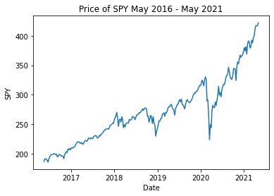

```python
#Built-in line plot method. Seaborn was imported as sns for short
plt = sns.lineplot(x=data['Date'], y=data['Adj Close'])
#Setting my labels
plt.set(xlabel="Date", ylabel="SPY", title="Price of SPY May 2016 - May 2021")
print(plt)
```

Here we can see the price movement of SPY over the last 5 years. This is graph is actually important to note because, if you recall, our iron condor strategy is based on the predictibility of price movements of the underlying. The iron condor is most profitable when volatility ends up being LOWER than expected. The S&P 500 is know for its diversification and steady, reliable increase over time. However, over the past two years, it looks like volatility has crazy (both negative and positive moves seem to be fairly harsh). This will be important to take into account when considering whether or not the S&P 500 will continue the same behavior as our analysis, or if we think it will start moving more or less erratically week by week.

Next, let's look at two different violin plots, first of all the SPY weeklyReturns over the past 5 years, and then grouped by year:

```
AxesSubplot(0.125,0.125;0.775x0.755)
```

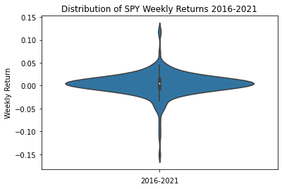

```python
#weeklyReturn on the y-axis of this singular violin plot
plt2 = sns.violinplot(y=data['weeklyReturn'],widths=10,showmeans=True)
#Setting my labels
plt2.set(xlabel="2016-2021", ylabel="Weekly Return", title="Distribution of SPY Weekly Returns 2016-2021")
print(plt2)
```

```
AxesSubplot(0.125,0.125;0.775x0.755)
```

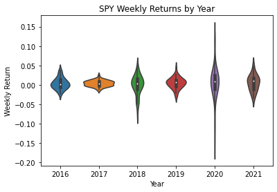

```python
#Extracting the year
data['Date'] = pd.to_datetime(data['Date'])
data['Date'][0].year
data['Years'] = pd.DatetimeIndex(data['Date']).year
#Years on the x-axis, weeklyReturn on y-axis
plt3 = sns.violinplot(y=data['weeklyReturn'],x=data['Years'],widths=10,showmeans=True)
#Setting my labels
plt3.set(xlabel="Year", ylabel="Weekly Return", title="SPY Weekly Returns by Year")
print(plt3)
```

What these two violin plots show us is the distribution of SPY weekly returns, first in aggregate and then grouped by year. To group it by year, I had to extract the year from each date, doing so by converting the date column into datetime, which can be read about [here](https://docs.python.org/3/library/datetime.html).  
It is clear that the distirbutions are all grouped around 0, which is to be expected. If we look closer, I expect the mean is slightly slightly above 0 because the S&P 500 does return around 8% per year. The weekly returns compound on top of themselves for 52 weeks to get to that 8% number, so that is why weekly returns are obviously much lower than the overall year return.  
One of the reasons I created the violin plot grouped by year was to look closer at my theory that volatility has increased over the last couple of years. Based on what I am looking at, I am actually led to believe that Covid is one of the major causes of that volatility, and it behavior will return to normal in the future. 2021 still does seem to have a slightly more spread distribution than, say, 2016 or 2017, but we have only gotten through the first 5 months of the year. Just to make sure, I think I will run a regression on the absolute values of the weekly returns over time. Of course regressions, confidence intervals, and hypothesis tests all fall under the next stage of the data science pipeline! With that, I think I am happy with my exploratory analysis and want to dig into these tests:

**IV. Hypothesis Testing & Machine Learning**

For my purposes, I will not be needing any significant machine learning (sorry). Instead, I can focus on the basis: finding both a 90% and 95% confidence interval on the weekly returns, and trying to see if there is a significant trend in volatility over time.

The purpose of the confidence intervals: If we can find an interval within which we expect, with confidence, SPY to stay each and every week, we could use those expected moves to help place both sides of our iron condor options strategy. For example, if SPY is at \$400, and we find that the 95% confident interval for weekly price movement is [-5%, 5%], then we can bet with fairly high confidence that SPY will not move above \$420 or below \$380 within the next week. Then, we can make a bet and start churning in profit.

Vital to note, however, is that if we continue making these bets every single week of the year, there WILL be weeks in which our bet is incorrect and SPY moves above or below our interval. For that reason, the iron condor takes more than just confidence. Specifically, a statistics-based or probabilistic iron condor strategy would be foolish if not to include a loss-management policy. Beyond the scope of this analysis, but there are ways to further hedge against our iron condor position in the case that SPY makes a large move in one particular week. I hope to further explore this strategy, possibly creating an automated trading bot with loss-management, in the future. For now, let's focus on these confidence intervals and regression to see what is going on with the data:

```python
#Using statsmodels built-in t-test confidence intervals
dws = sm.stats.DescrStatsW(data['weeklyReturn'])
#Just created a StatsModels DescrStatsW object
#That object has the built in confidence interval functions
#Now simply printing the results on confidence intervals with three
# different confidence levels
print("The 95% confidence interval is ")
print(dws.tconfint_mean(alpha=.05))
print("\n")
print("The 90% confidence interval is ")
print(dws.tconfint_mean(alpha=.1))
print("\n")
print("The 97.5% confidence interval is ")
print(dws.tconfint_mean(alpha=.025))
print("\n")
```

```
The 95% confidence interval is
(0.0003401512191378987, 0.006471755786933613)


The 90% confidence interval is
(0.0008358810985208674, 0.005976025907550645)


The 97.5% confidence interval is
(-0.00010410083838108177, 0.006916007844452594)
```

Okay, great. Above you can see that I used StatsModels (my personal choice in terms of Python stats packages) to print out the 90%, 95%, and 97.5% confident intervals on the weeklyReturn of SPY. For documentation on StatsModels, click [here](https://www.statsmodels.org/stable/index.html).  
At 90% confidence, the weekly move of SPY is expected to be between .08% and .6%. At 95% confidence, the weekly move of SPY is expected to be between .03% and .65%. Finally, at 97.5% confidence, the weekly move of SPY is expected to be between -.01 and .7%.

Before I start communicating the findings and going more in-depth to what this might mean if we wanted to perform a probabilistic iron condor strategy, I did want to run a regression on volatility over time. To do this, I will again be utilizing StatsModels and their built in linear regression:

```python
#Finding the absolute values of the weekly returns
data['weeklyRetAbs'] = data['weeklyReturn'].abs()
data.head()
```

|  | Date | Open | High | Low | Close | Adj Close | Volume | weeklyReturn | Years | weeklyRetAbs |
| --- | --- | --- | --- | --- | --- | --- | --- | --- | --- | --- |
| 0 | 2016-05-16 | 204.960007 | 207.339996 | 202.779999 | 205.490005 | 186.922195 | 532894700 | 0.023116 | 2016 | 0.023116 |
| 1 | 2016-05-23 | 205.509995 | 210.250000 | 204.990005 | 210.240005 | 191.243011 | 348333700 | 0.000190 | 2016 | 0.000190 |
| 2 | 2016-05-30 | 210.559998 | 210.929993 | 208.860001 | 210.279999 | 191.279388 | 344617400 | -0.000999 | 2016 | 0.000999 |
| 3 | 2016-06-06 | 210.699997 | 212.520004 | 209.429993 | 210.070007 | 191.088379 | 379648800 | -0.016899 | 2016 | 0.016899 |
| 4 | 2016-06-13 | 209.360001 | 210.369995 | 205.589996 | 206.520004 | 187.859131 | 618523800 | -0.010764 | 2016 | 0.010764 |

```
AxesSubplot(0.125,0.125;0.775x0.755)
```

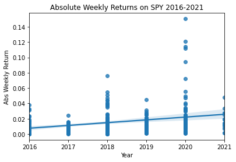

```python
#Seaborn regression plot, with Year on x-axis and weekly returns on y-axis
#I choose to include the scatter plot as well as the best-fit line
plt4 = sns.regplot(data=data, y='weeklyRetAbs',x='Years',scatter=True,fit_reg=True)
#Setting the labels on my plot
plt4.set(xlabel="Year", ylabel="Abs Weekly Return", title="Absolute Weekly Returns on SPY 2016-2021")
print(plt4)
```

Here is a quick regplot from the Seaborn package. I like to visualize the regression before actually calculating it. As we can see, it looks like volatility actually has been trending upward over time, although it is still unclear if this is natural or somewhat biased by the crazy 2020 volatility.  
Now, we will use StatsModels to run a regression on the two variables of absolute weekly return and year to see if volatility has increased over time, with statistical significance:

```python
#Cool trick to use statsmodels OLS for regression
#The 'weeklyRetAbs ~ Years' formula basically puts
#weeklyRetAbs as the dependent variable and Years
#as the independent variable
fit_results = ols.ols(formula="weeklyRetAbs ~ Years", data=data).fit()
print(fit_results.summary())
```

```
                            OLS Regression Results
==============================================================================
Dep. Variable:           weeklyRetAbs   R-squared:                       0.077
Model:                            OLS   Adj. R-squared:                  0.073
Method:                 Least Squares   F-statistic:                     21.45
Date:                Mon, 17 May 2021   Prob (F-statistic):           5.77e-06
Time:                        19:11:49   Log-Likelihood:                 666.39
No. Observations:                 260   AIC:                            -1329.
Df Residuals:                     258   BIC:                            -1322.
Df Model:                           1
Covariance Type:            nonrobust
==============================================================================
                 coef    std err          t      P>|t|      [0.025      0.975]
------------------------------------------------------------------------------
Intercept     -7.2912      1.578     -4.621      0.000     -10.398      -4.184
Years          0.0036      0.001      4.631      0.000       0.002       0.005
==============================================================================
Omnibus:                      211.533   Durbin-Watson:                   1.299
Prob(Omnibus):                  0.000   Jarque-Bera (JB):             2908.526
Skew:                           3.270   Prob(JB):                         0.00
Kurtosis:                      18.024   Cond. No.                     2.74e+06
==============================================================================

Warnings:
[1] Standard Errors assume that the covariance matrix of the errors is correctly specified.
[2] The condition number is large, 2.74e+06. This might indicate that there are
strong multicollinearity or other numerical problems.
```

From the regression we can see that there is a statistically significant coefficient for Years, with a p-value less than .001 ! (You can see this in the middle section of the results under the header "P > |t|". This means that most certainly, volatility is going up year by year, at least over the last five years. This does impact the way that we think about a probabilistic iron condor strategy, because we cannot be sure that the confidence intervals we have pulled from the historical data will stay the same. SPY could easily start bouncing up and down with more volatility, but I will talk more about this connection in the final section of the pipeline:

**V. Communication of Insight Attained**

Finally, I just wanted to mention the extremely statistically significant relationship we found between volatility and time. Although volatility is rising slowly, if the trend continues, the intervals we have found based on historical data will not longer be valid! The next step to this analysis is to actually predict by how much more volatility will increase in the coming years, and adjust a potential iron condor strategy accordingly (i.e. expand the bounds of the strategy to have higher confidence of success taking into account higher volatility).

At the end of the day, I figured out that it is absolutely possible to use historical data to start building my probabilistic options trading strategy. We could start doing similar analyses with other stocks, or begin using similar analysis to price options and find [arbitrage opportunities](https://www.investopedia.com/articles/optioninvestor/05/011905.asp) using the [black-scholes parity method](http://www.columbia.edu/~mh2078/FoundationsFE/BlackScholes.pdf).

**Conclusion**  
Finally, we have walked through all 5 sections of the data science pipeline. I recevied many insights both about the behavior of SPY and volatility in the markets since 2016. As the last step of the tutorial, we will transform this notebook into static HTML and upload it to the internet for everyone to see. I am going to do this using my personal website, which is built through Squarespace. Using a simple code block, I can upload this entire notebook statically. And for more information about how to convert Google Colab notebooks into HTML, check out this [stack overflow link](https://stackoverflow.com/questions/53460051/convert-ipynb-notebook-to-html-in-google-colab).

If you have been so gracious as to have read through this entire tutorial, I thank you, and hope that you found the analysis interesting. For more information about Python, visit https://www.python.org/about/gettingstarted/. For more information about SPY, you can visit [Yahoo Finance](https://finance.yahoo.com/quote/SPY/). If you are interested in data science, I would check out some of the resources University of Maryland provides on the subject, as well as possibly take a course or two online! There are many. Lastly, if you have any further questions about options, the financial markets, or for me in general, feel free to contact me via the contact form on my website above. Thanks for reading, and have a good day!